# Complete Source Code for 2013 phyloseq Manuscript

This is an [R Markdown](http://www.rstudio.com/ide/docs/authoring/using_markdown) document creating the graphics in this manuscript. Markdown is a simple formatting syntax for authoring web pages. Try [RStudio](http://www.rstudio.com/) for writing and interpreting R Markdown documents.

# Load required packages

```r
library("phyloseq")
library("ggplot2")
library("scales")
library("grid")
```

Should be using phyloseq version `1.3.20` or greater for reliable behavior. See [the phyloseq homepage](http://joey711.github.com/phyloseq/)

```r
packageVersion("phyloseq")
```

```
## [1] '1.3.20'
```

```r
packageVersion("ggplot2")
```

```
## [1] '0.9.3'
```

```r
packageVersion("scales")
```

```
## [1] '0.2.3'
```

```r
packageVersion("grid")
```

```
## [1] '2.15.2'
```

```r
packageVersion("knitr")
```

```
## [1] '1.1'
```

# Preprocess phyloseq data for plotting

The following is the complete set of preprocessing steps that was applied to the `GlobalPatterns` OTU counts prior to creating the figures in the 2013 phyloseq manuscript. See [the tutorial on preprocessing](http://joey711.github.com/phyloseq/preprocess) for further details and examples.

Load the `GlobalPatterns` dataset into the workspace.

```r
data("GlobalPatterns")
```

Define a human versus non-human categorical variable, store this as a 2-category factor in the sample data.

```r
sample_data(GlobalPatterns)$human = factor(sample_data(GlobalPatterns)$SampleType %in%
    c("Feces", "Mock", "Skin", "Tongue"))
```

Remove taxa not seen more than 3 times in at least 20% of the samples. This helps protect against an OTU with small mean & trivially large Coefficient of Variation. Save this as new phyloseq data object, `GP`.

```r
GP = filter_taxa(GlobalPatterns, function(x) sum(x > 3) > (0.2 * length(x)),
    TRUE)
```

Transform abundances to the median sequencing depth.

```r
total = median(sample_sums(GP))
standf = function(x, t = total) round(t * (x/sum(x)))
gps = transform_sample_counts(GP, standf)
```

Filter the taxa using a cutoff of `3.0` for the Coefficient of Variation.

```r
gpsf = filter_taxa(gps, function(x) sd(x)/mean(x) > 3, TRUE)
```

Subset the data to “Bacteroidetes-only”“, used in some plots, called `gpsfb`.

```r
gpsfb = subset_taxa(gpsf, Phylum == "Bacteroidetes")
```

Save the preprocessed data, in case you want to skip this step in the future.

```r
save(gpsf, gpsfb, file = "gp-ex.RData")
```

Check for existence of submit-main directory. If not present, create it.

```r
main_figure_dir_name = "submit-main"
if (!file.exists(main_figure_dir_name)) {
    dir.create(main_figure_dir_name)
}
```

# Figure 4

# Create graphics for main plot

Create the six example plots in the main plot figure for phyloseq manuscript

Define the base theming you want to use across all plots

```r
theme_set(theme_bw())
```

## 1 plot_ordination

See [the plot_ordination tutorial](http://joey711.github.com/phyloseq/plot_ordination-examples) for more details, examples.

Perform [NMDS](http://en.wikipedia.org/wiki/Multidimensional_scaling) on [weighted UniFrac distance](http://bmf.colorado.edu/unifrac/help.psp). This is a Bacteroidetes-only subset of the data.

```r
gpsfb.wUF = distance(gpsfb, "unifrac", weighted = TRUE)
gpsfb.NMDS = ordinate(gpsfb, "NMDS", gpsfb.wUF)
```

```
## ... procrustes: rmse 0.002305  max resid 0.008574
## *** Solution reached
```

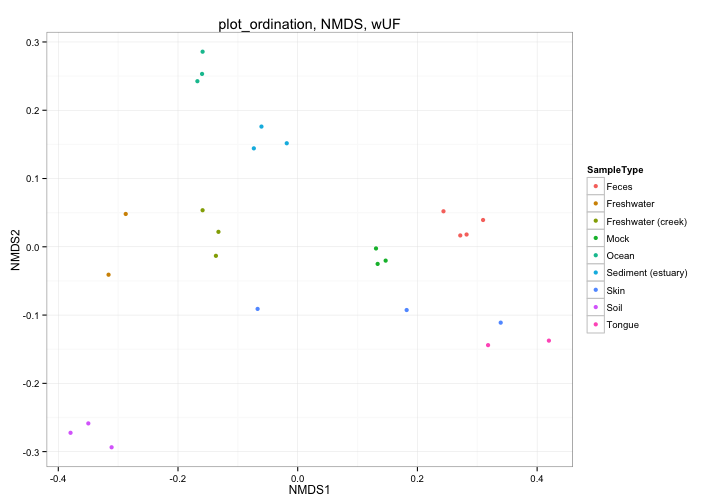

```r
p1 = plot_ordination(gpsfb, gpsfb.NMDS, "samples", color = "SampleType", title = "plot_ordination, NMDS, wUF")
p1
```

Add fill to emphasize regions and overlap

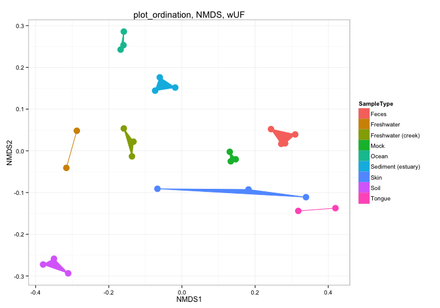

```r
p1 = p1 + geom_polygon(aes(fill = SampleType)) + geom_point(size = 5)
p1
```

## 2 plot_heatmap

See [the plot_heatmap tutorial](http://joey711.github.com/phyloseq/plot_heatmap-examples) for more details, examples.

Create the heatmap on the full dataset, using Bray-Curtis distance and NMDS.

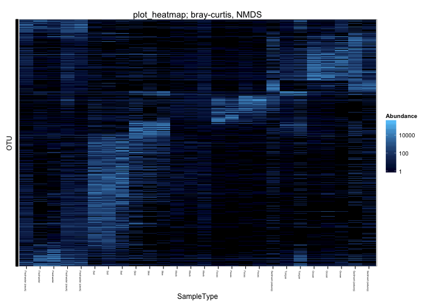

```r
title = "plot_heatmap; bray-curtis, NMDS"
p2 = plot_heatmap(gpsf, "NMDS", "bray", "SampleType", trans = log_trans(10),
    title = title)
p2
```

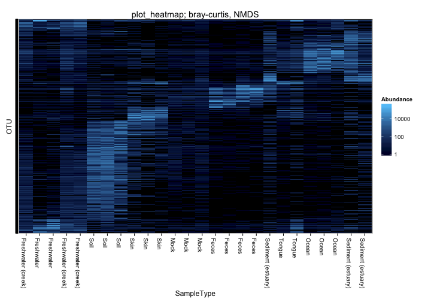

```r
p2 = p2 + theme(axis.text.x = element_text(size = 10, angle = -90, hjust = 0))
p2
```

## 3 plot_network

Example with the `plot_network` function using an example from the `enterotype` dataset. See [the plot_network tutorial](http://joey711.github.com/phyloseq/plot_network-examples) for further details and examples.

Load the `enterotype` dataset for this one, and clean it of the samples for which the original authors did not provide an "Enterotypes” designation.

```r
data("enterotype")
enterotype = subset_samples(enterotype, !is.na(Enterotype))
```

Now create the `igraph` network object, and build the network graphic.

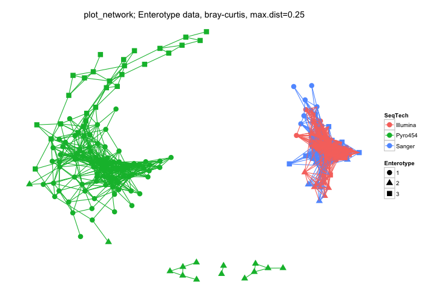

```r
mxdist = 0.25
ig = make_network(enterotype, "samples", "bray", max.dist = mxdist)
title = paste("plot_network; Enterotype data, bray-curtis, max.dist=", mxdist,
    sep = "")
p3 = plot_network(ig, enterotype, "samples", color = "SeqTech", shape = "Enterotype",
    line_weight = 0.5, label = NULL, title = title, line_alpha = 1)
p3
```

## 4 plot_tree

Example using `plot_tree` with the Bacteroidetes-only data, `gpsfb`, which will be further consolidated/simplified. See [the plot_tree tutorial](http://joey711.github.com/phyloseq/plot_tree-examples) for more details, examples.

Define the title for your tree.

```r
title = "plot_tree; Bacteroidetes-only. Merged samples, tip_glom=0.1"
```

Coerce the node labels to be proper bootstraps by rm perplexing suffix.

```r
head(phy_tree(gpsfb)$node.label)
```

```
## [1] "0.768.276" "0.361.73"  "0.924.733" "0.228.73"  "0.982.388" "0.957.400"
```

```r
phy_tree(gpsfb)$node.label = substr(phy_tree(gpsfb)$node.label, 1, 4)
head(phy_tree(gpsfb)$node.label)
```

```
## [1] "0.76" "0.36" "0.92" "0.22" "0.98" "0.95"
```

Not finished for the figure, and too busy/crowded a graphic, but let's document what that looks like, anyway.

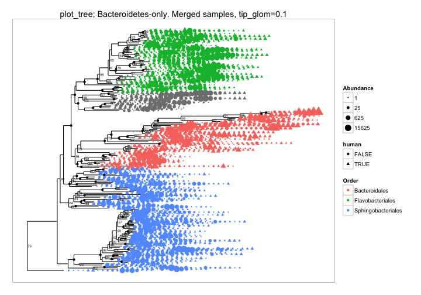

```r
plot_tree(gpsfb, "sampledodge", nodeplotboot(), "Order", "human", "abundance",
    title = title, ladderize = "left")
```

Yep, too many tips for display in the available space in the main plot of the manuscript. Consolidate the data for the tree into new object, called `tggpsfb`. First by agglomerating OTUs that are similar enough to have a patristic distance less than `0.1`. Second, merge samples that come from the same `SampleType` (environment), as we are mostly interested in comparing between environments, and we already know that the microbiome profiles from the same `SampleType` in this dataset are very similar relative to the between `SampleType` differences.

```r
tggpsfb = tip_glom(gpsfb, NULL, 0.1)
tggpsfb = merge_samples(tggpsfb, "SampleType")
```

Repair the data factors that we want to use. They tend to be coerced to something other than factors during `data.frame` `merge`.

```r
sample_data(tggpsfb)$human = factor(sample_names(tggpsfb) %in% c("Feces", "Mock",
    "Skin", "Tongue"))
sample_data(tggpsfb)$SampleType = factor(sample_names(tggpsfb))
```

Compare two different aesthetic mappings for the tree. We will go with the latter for the publication graphic, but it's interesting to compare the two.

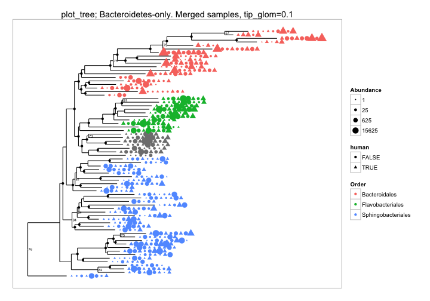

```r
plot_tree(tggpsfb, "sampledodge", nodeplotboot(85L, 60L), "Order", "human",
    "abundance", title = title, ladderize = "left")
```

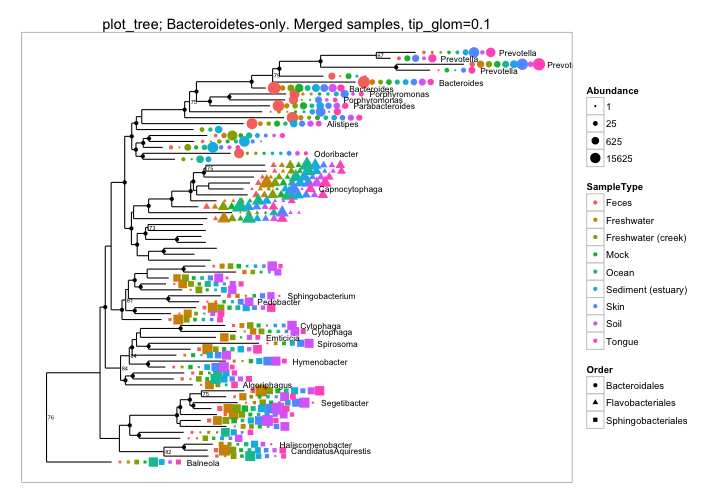

```r
p4 = plot_tree(tggpsfb, "sampledodge", nodeplotboot(85L, 60L), "SampleType",
    "Order", "abundance", title = title, ladderize = "left", label.tips = "Genus")
p4
```

## 5 plot_bar

Example of `plot_bar` using the Bacteroidetes-only subset, `gpsfb`. The horizontal position is mapped to `SampleType`, the vertical axis mapped to OTU abundance value, and the box fill is mapped to taxonomic family of each OTU. See [the plot_bar tutorial](http://joey711.github.com/phyloseq/plot_bar-examples) for more details, examples.

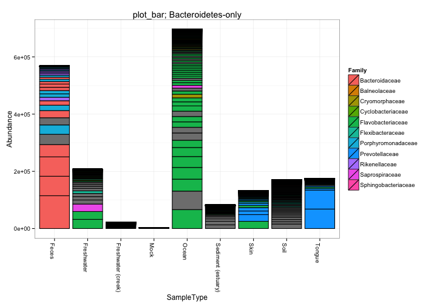

```r
title = "plot_bar; Bacteroidetes-only"
p5 = plot_bar(gpsfb, "SampleType", "Abundance", "Family", title = title)
p5
```

## 6 plot_richness

Example of `plot_richness` using the original unfiltered `GlobalPatterns` dataset. See [the plot_richness tutorial](http://joey711.github.com/phyloseq/plot_richness-examples) for more details, examples.

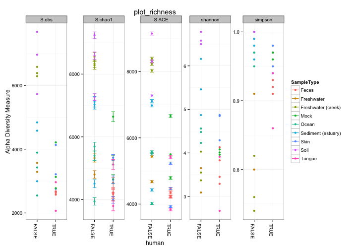

```r
plot_richness(GlobalPatterns, "human", "SampleType", title = "plot_richness",
    shsi = TRUE)
```

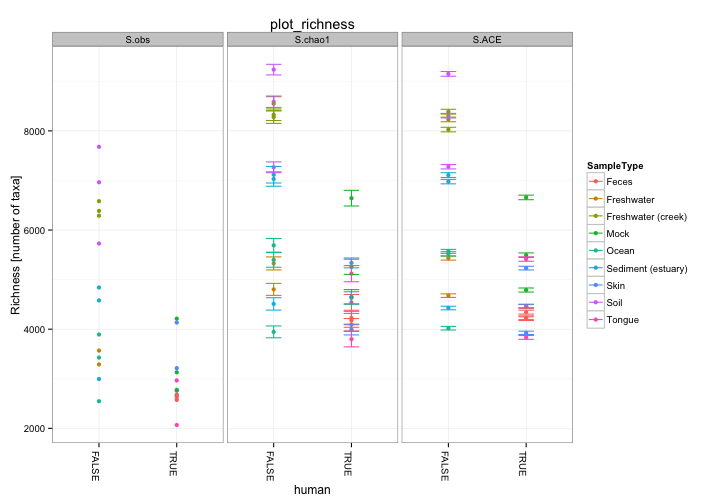

```r
p6 = plot_richness(GlobalPatterns, "human", "SampleType", title = "plot_richness")
p6
```

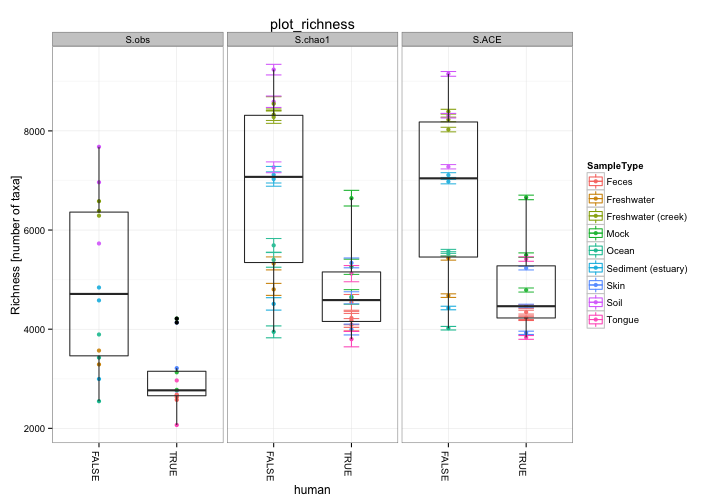

```r
p6 + geom_boxplot(data = p6$data, aes(x = human, y = value, color = NULL), alpha = 0.1)
```

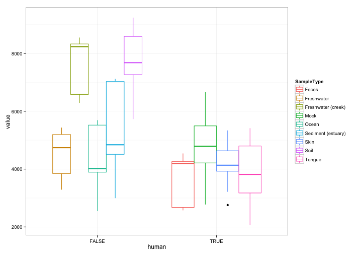

```r
p6 = ggplot(p6$data, aes(x = human, y = value, color = SampleType)) + geom_boxplot(alpha = 0.1)
p6
```

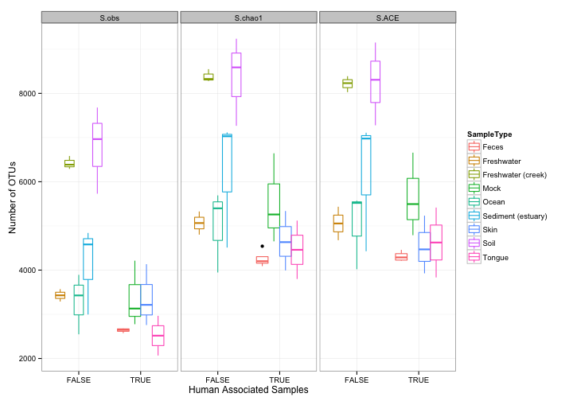

```r
p6 = p6 + facet_wrap(~variable, nrow = 1) + xlab("Human Associated Samples") +
    ylab("Number of OTUs")
p6
```

# Combine main plot and save

This requires the grid package, which was loaded at the very beginning on this tutorial. The following code combines each of the previous individual plots (the final versions) into one larger graphic for publication, especially `grid.newpage`, `pushViewport`, and `viewport`. The first step is to create the viewport defining the graphics grid. Then loop through and add each of the previous ggplot graphics to this PDF/viewport grid.

First embed an example of the graphic directly into this tutorial web document.

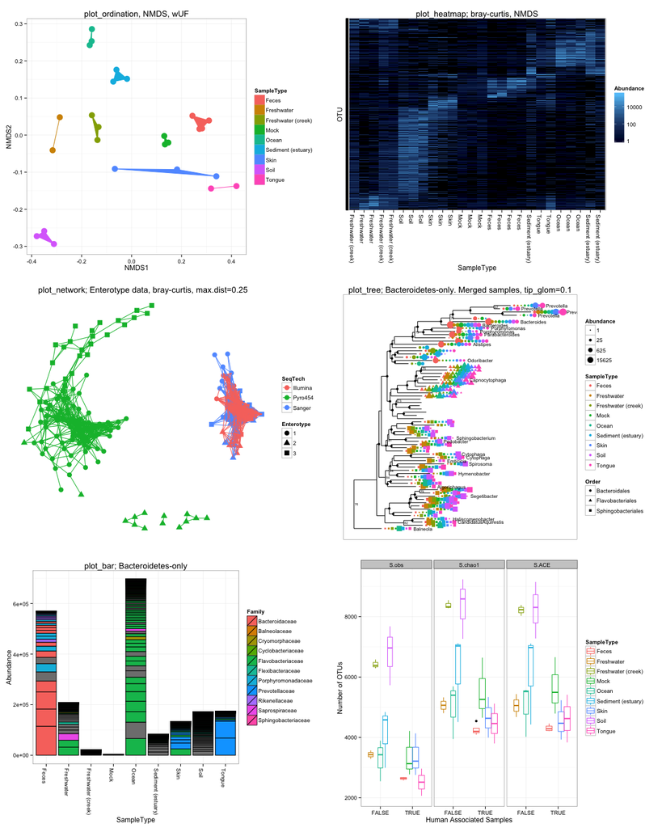

```r
grid.newpage()
pushViewport(viewport(layout = grid.layout(3, 2)))
i = 1
for (x in 1:3) {
    for (y in 1:2) {
        p_i = eval(parse(text = paste("p", i, sep = "")))
        print(p_i, vp = viewport(layout.pos.row = x, layout.pos.col = y))
        i = i + 1
    }
}
```

```r
# Always turn-off/close-connection-with the graphics device when finished.
dev.off()
```

Now repeat the same code as above, but brace with the `pdf` and `dev.off` functions in order to send the combined graphic to a file for publication. Note that `png()` could also work in place of `pdf()` if raster graphic needed.

```r
pdf(paste(main_figure_dir_name, "phyloseq-plot-main.pdf", sep = "/"), width = 16,
    height = 20)
grid.newpage()
pushViewport(viewport(layout = grid.layout(3, 2)))
i = 1
for (x in 1:3) {
    for (y in 1:2) {
        p_i = eval(parse(text = paste("p", i, sep = "")))
        print(p_i, vp = viewport(layout.pos.row = x, layout.pos.col = y))
        i = i + 1
    }
}
# Always turn-off/close-connection-with the graphics device when finished.
dev.off()
```

# Figure 5

# Ordination plots

Make ordination plots for ordination figure.

Perform correspondence analysis.

```r
GP.ca = ordinate(gpsfb, method = "CCA")
```

Define the default alpha (transparency, `{0, 1}`) to use for plot points

```r
alpha = 0.75
```

Define a default color pallete using `rainbow()`. In all plots, color is mapped to `SampleType` variable, sometimes plus an extra for taxa or samples.

```r
color_var = get_variable(gpsfb, "SampleType")
color_pal = rainbow(length(levels(color_var)) + 1)
names(color_pal) = c(levels(color_var), "taxa")
color_pal["taxa"] = "black"
```

Similarly, define a standard shape-scale

```r
shape_var = get_taxa_unique(gpsfb, "Class")
shape_scale = c(0:2, 19)
names(shape_scale) = c(shape_var, "samples")
```

## 0 plot_ordination - scree plot

Must have loaded the grid package for the `unit` function (we did at the beginning).

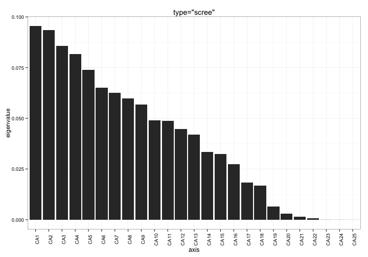

```r
p0 = plot_ordination(gpsfb, GP.ca, "scree", title="type=\"scree\"")
p0
```

Modify some aspects of the theme for this plot, especially removing certain elements from the axes. Unit arguments for `plot.margin` have the form `c("top", "right", "bottom", "left")`.

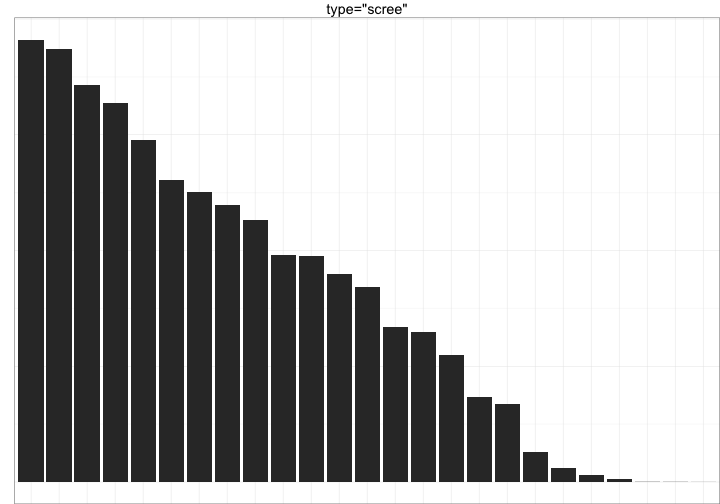

```r
b = element_blank()
p0 = p0 + theme(axis.title = b, axis.ticks = b, axis.text = b, panel.background = b,
    plot.margin = unit(c(0, 0, -1, 0), "lines"))
p0
```

## 1 plot_ordination - samples-only

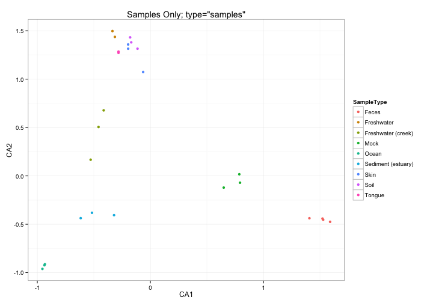

```r
p1 = plot_ordination(gpsfb, GP.ca, "samples", color="SampleType", title="Samples Only; type=\"samples\"")
p1
```

Add the enlarged point size

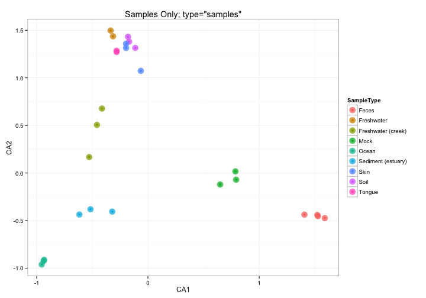

```r
p1 = p1 + geom_point(size = 5, alpha = alpha)
p1
```

Remove the original non-transparent, small-size `geom_point` layer.

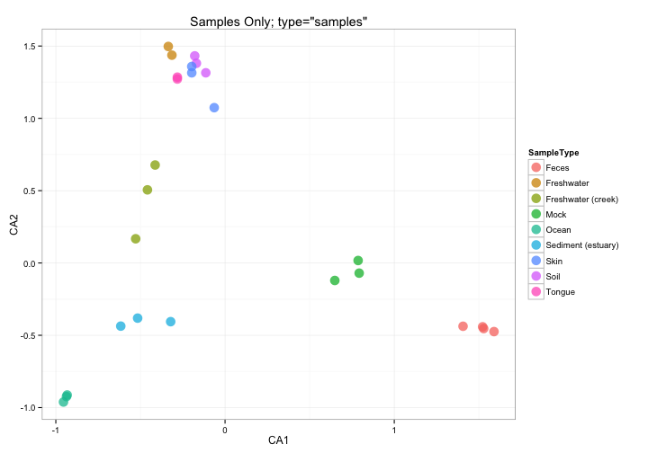

```r
p1$layers = p1$layers[-1]
p1
```

Add the filled polygon

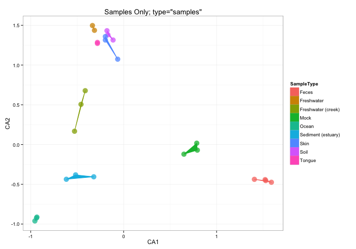

```r
p1 = p1 + geom_polygon(aes(fill = SampleType))
p1
```

Set the manual color scale from `color_pal`.

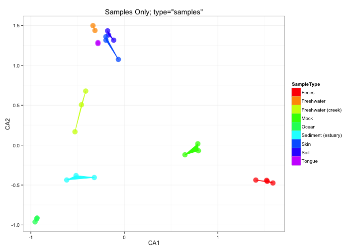

```r
p1 = p1 + scale_colour_manual(values = color_pal) + scale_fill_manual(values = color_pal)
p1
```

## 2 plot_ordination - biplot

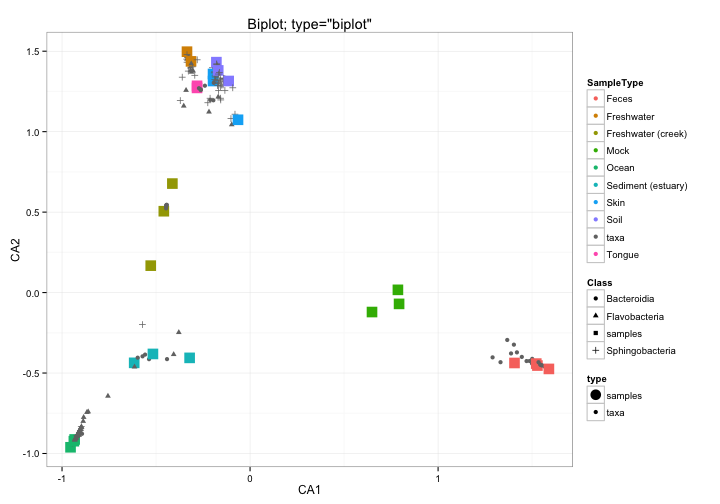

```r
p2 = plot_ordination(gpsfb, GP.ca, "biplot", color="SampleType", shape="Class", title="Biplot; type=\"biplot\"")
p2
```

Re-order the color elements in legend.

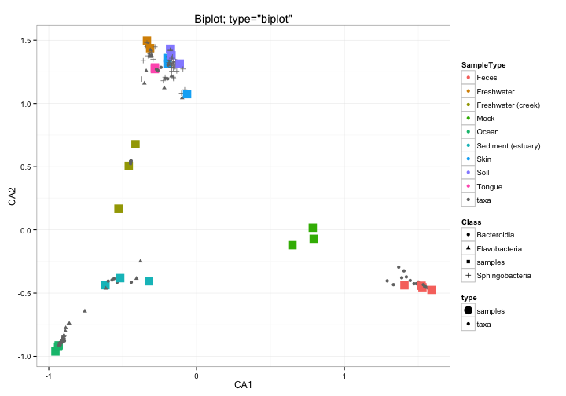

```r
stleg = as(p2$data$SampleType, "character")
stleg = factor(stleg, levels = c(levels(get_variable(gpsfb, "SampleType")),
    "taxa"))
p2$data$SampleType = stleg
p2
```

Add the layer defining the custom color scale/pallete

```r
p2 = p2 + scale_colour_manual(values = color_pal)
```

[output not shown]

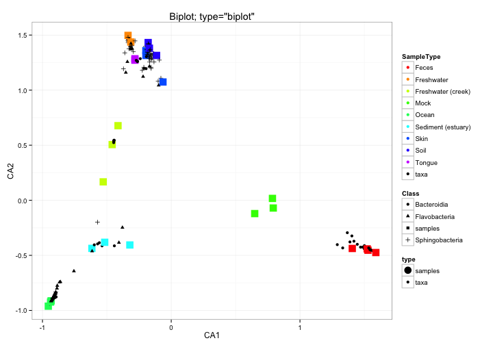

```r
p2
```

Re-order the shape elements in legend.

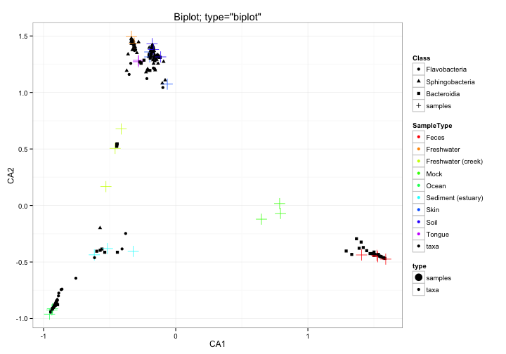

```r
cleg = as(p2$data$Class, "character")
cleg = factor(cleg, levels = c(unique(cleg[cleg != "samples"]), "samples"))
p2$data$Class = cleg
p2
```

Set manual shape scale, using previously-defined `shape_var`.

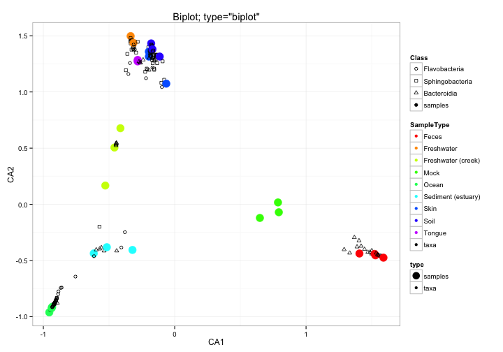

```r
p2 = p2 + scale_shape_manual(values = shape_scale)
p2
```